# MIA Data Preparation and Analysis

Author

Ray Erickson

Published

May 10, 2026

# Setup, Aggregation, and Base Visualization

> For this project you will need the `pandas`, `matplotlib.pyplot`, `us`, `geopandas`, and `re` libraries

Due to the size of some of the maps, they are included as links to html files hosted in this github folder. As of yet, they are not automatically up to date, but I should be fairly on top of making sure they are the latest versions I have made.

**Data Importation & Cleaning**

**Importing Original Files**

```python
byalph = pd.read_excel(file, "A-Z", index_col=None, na_values=["NA"])
```

This call reads the excel file, specifically the sheet named “A-Z” into a dataframe without a predefined index and includes no special variables to be assigned as missing values.

Sheet *A-Z* is the compiled list of the MIA individuals downloaded alphabetically

```
<class 'pandas.DataFrame'>
RangeIndex: 84603 entries, 0 to 84602
Data columns (total 6 columns):
 #   Column          Non-Null Count  Dtype
---  ------          --------------  -----
 0   Last_Name       84603 non-null  str
 1   First_Name      84603 non-null  str
 2   Conflict        84603 non-null  str
 3   Service         84603 non-null  str
 4   Service_Number  83527 non-null  object
 5   Home_of_Record  82845 non-null  str
dtypes: object(1), str(5)
memory usage: 3.9+ MB
```

```python
bystate = pd.read_excel(file, "AL-WY", index_col=None, na_values=["NA"])
```

This call reads the excel file, specifically the sheet named “AL-WY” into a dataframe without a predefined index and includes no special variables to be assigned as missing values.

Sheet AL-WY is the compiled list of the MIA individuals downloaded by state.

```
<class 'pandas.DataFrame'>
RangeIndex: 74631 entries, 0 to 74630
Data columns (total 8 columns):
 #   Column        Non-Null Count  Dtype
---  ------        --------------  -----
 0   Last_Name     74631 non-null  str
 1   First_Name    74608 non-null  str
 2   Conflict      74631 non-null  str
 3   State         74631 non-null  str
 4   Date_of_Loss  73765 non-null  str
 5   Location      53656 non-null  str
 6   Rank          74548 non-null  str
 7   Unit          74549 non-null  str
dtypes: str(8)
memory usage: 4.6 MB
```

**Merging Files into a single DB**

```python
merged = byalph.merge(bystate, how='outer', on=["Last_Name","First_Name","Conflict"])
```

This code merges the state and alphabetical dataframes based on the `First_Name`, `Last_Name`, and `Confict`, as these are the only columns that exist on both sheets, as well as being the standardized ones, and generally have no nulls. Since they are not in and of themselves unique, the combination of all three is needed to appropriately merge the dataframes.

```
<class 'pandas.DataFrame'>
RangeIndex: 89790 entries, 0 to 89789
Data columns (total 11 columns):
 #   Column          Non-Null Count  Dtype
---  ------          --------------  -----
 0   Last_Name       89790 non-null  str
 1   First_Name      89767 non-null  str
 2   Conflict        89790 non-null  str
 3   Service         89015 non-null  str
 4   Service_Number  87925 non-null  object
 5   Home_of_Record  87251 non-null  str
 6   State           76766 non-null  str
 7   Date_of_Loss    75893 non-null  str
 8   Location        55033 non-null  str
 9   Rank            76680 non-null  str
 10  Unit            76681 non-null  str
dtypes: object(1), str(10)
memory usage: 7.5+ MB
```

**Cleaning**

The dataframe has some quantity of duplicates, likely due to some amount of syntactical differences, ex. name has a middle initial on one and not the other, etc…

```python
cleaned = merged.drop_duplicates(subset=["Last_Name", "Service_Number"])
```

drop duplicates based upon service number, with last name as a index in order to not drop all null service numbers as duplicates

```
<class 'pandas.DataFrame'>
Index: 85083 entries, 0 to 89789
Data columns (total 11 columns):
 #   Column          Non-Null Count  Dtype
---  ------          --------------  -----
 0   Last_Name       85083 non-null  str
 1   First_Name      85060 non-null  str
 2   Conflict        85083 non-null  str
 3   Service         84451 non-null  str
 4   Service_Number  83526 non-null  object
 5   Home_of_Record  82811 non-null  str
 6   State           72184 non-null  str
 7   Date_of_Loss    71356 non-null  str
 8   Location        51877 non-null  str
 9   Rank            72114 non-null  str
 10  Unit            72107 non-null  str
dtypes: object(1), str(10)
memory usage: 7.8+ MB
```

```python
cleaned = cleaned.drop(cleaned[(cleaned.Home_of_Record == "NON-US")].index)
```

Drop all records that have the `home of record` listed as Non-US, narrowing the dataframe to only those from the US

```
<class 'pandas.DataFrame'>
Index: 80494 entries, 0 to 89789
Data columns (total 11 columns):
 #   Column          Non-Null Count  Dtype
---  ------          --------------  -----
 0   Last_Name       80494 non-null  str
 1   First_Name      80471 non-null  str
 2   Conflict        80494 non-null  str
 3   Service         79862 non-null  str
 4   Service_Number  78942 non-null  object
 5   Home_of_Record  78222 non-null  str
 6   State           72177 non-null  str
 7   Date_of_Loss    71349 non-null  str
 8   Location        51870 non-null  str
 9   Rank            72107 non-null  str
 10  Unit            72100 non-null  str
dtypes: object(1), str(10)
memory usage: 7.4+ MB
```

```python
cleaned = cleaned.dropna(subset = ["State","Conflict"])
```

Drop all records that have null values in the `State` field as they will not be useful for analysis

```
<class 'pandas.DataFrame'>
Index: 72177 entries, 0 to 89789
Data columns (total 11 columns):
 #   Column          Non-Null Count  Dtype
---  ------          --------------  -----
 0   Last_Name       72177 non-null  str
 1   First_Name      72154 non-null  str
 2   Conflict        72177 non-null  str
 3   Service         71545 non-null  str
 4   Service_Number  71431 non-null  object
 5   Home_of_Record  71529 non-null  str
 6   State           72177 non-null  str
 7   Date_of_Loss    71349 non-null  str
 8   Location        51870 non-null  str
 9   Rank            72107 non-null  str
 10  Unit            72100 non-null  str
dtypes: object(1), str(10)
memory usage: 6.6+ MB
```

Additionally, while the Army Air Force and the Air Force are technically different entities, because the Army Air Force is the Air Force precursor, for analysis purposes, I have combined the two together.

**Anonomizing Data**

```python
todrop = ["Last_Name", "First_Name", "Service_Number", "Unit", "Home_of_Record", "Rank"]
anon = cleaned.drop(columns=todrop)
```

Drop the names and service numbers in order to anonomize data, as well as Unit, since the unit data is not currently standardized and to do so would take massive amounts of time, and Home of Record since it is duplicated by state to a degree and state is a more accurate identifier, and Rank since its not standardized, nor currently in use in this analysis

```python
anon["Date_of_Loss"]=pd.to_datetime(anon["Date_of_Loss"])
anon["Year_of_Loss"]=anon["Date_of_Loss"].dt.year
anon["Date_of_Loss"]=anon["Date_of_Loss"].dt.date
anon["State_Name"] = anon["State"].map(lambda x: us.states.lookup(x).name)
```

I am also making sure the `Date of Loss` column is in DateTime format and then making it only have the date not a unneeded time value, and adding a `Year of Loss` column for added analysis options. As well as adding a `State Name` column for ease of understanding.

```
<class 'pandas.DataFrame'>
Index: 72177 entries, 0 to 89789
Data columns (total 7 columns):
 #   Column        Non-Null Count  Dtype
---  ------        --------------  -----
 0   Conflict      72177 non-null  str
 1   Service       71545 non-null  str
 2   State         72177 non-null  str
 3   Date_of_Loss  71349 non-null  object
 4   Location      51870 non-null  str
 5   Year_of_Loss  71349 non-null  float64
 6   State_Name    72177 non-null  str
dtypes: float64(1), object(1), str(5)
memory usage: 4.4+ MB
```

I then export the anonomized data to an excel sheet to simplify further actions.

```python
anon.to_excel("mia_anon.xlsx")
```

**Data Aggregation**

First I am going to aggregate the data based upon the different main variables in order to make analysis easier at a later time. Additionally I am adding some additional reference values for sorting purposes

```
Missing count by conflict
                            Count  Start_Year  End_Year
Conflict
COLD WAR                      124        1947      1991
KOREAN WAR                   6980        1950      1953
OPERATION DESERT STORM          2        1991      1991
OPERATION EL DORADO CANYON      1        1986      1986
OPERATION IRAQI FREEDOM         2        2003      2011
VIETNAM WAR                  1485        1955      1975
WORLD WAR II                63583        1939      1945
```

```
Missing count by Service
                               Count
Service
CIVILIAN                          71
MARINE CORPS RESERVE             147
NAVY RESERVE                     325
UNITED STATES AIR FORCE        20470
UNITED STATES ARMY             17223
UNITED STATES COAST GUARD        540
UNITED STATES MARINE CORPS      3191
UNITED STATES MERCHANT MARINE     29
UNITED STATES NAVY             29549
```

```
Highest 10 State Missing Counts
       Count     State_Name
State
CA      6433     California
NY      6322       New York
PA      5295   Pennsylvania
IL      4163       Illinois
TX      4040          Texas
OH      3581           Ohio
MA      2892  Massachusetts
MI      2817       Michigan
NJ      2339     New Jersey
MO      2254       Missouri
```

```
Highest 10 Missing Counts by Year
              Count
Year_of_Loss
1944.0        22484
1943.0        13831
1945.0        13529
1942.0        11427
1950.0         3249
1951.0         1615
1941.0         1448
1952.0          875
1946.0          812
1953.0          517
```

```
Highest 10 Missing Counts by Date
              Count
Date_of_Loss
1944-10-24     1834
1942-11-13     1248
1942-03-01     1243
1942-08-09     1146
1941-12-07     1103
1944-10-25      871
1945-07-30      825
1944-12-18      807
1943-11-26      709
1943-11-24      657
```

```
Highest 10 State Missing Counts
                  Count
Location
Solomon Islands    5614
Philippines        5399
North Korea        5396
Japan              3903
Papua New Guinea   3190
United States      2912
France             2623
Italy              2403
Germany            2060
Indonesia          1881
```

To do further analysis I am also including the reserves within the main branch to simplify things a little

**Base Visualization**

**Missing per Conflict**

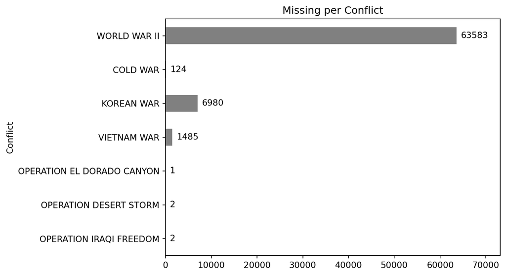

**Missing per Service**

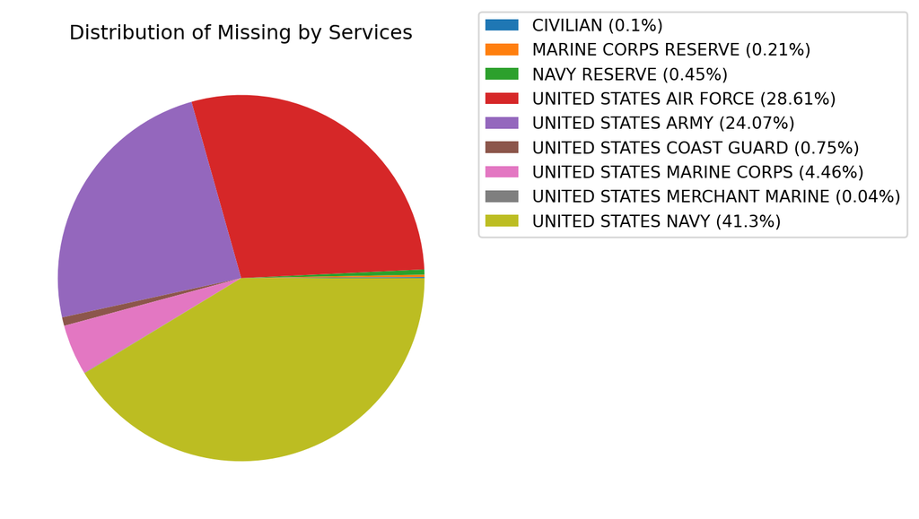

**Missing by Home State**

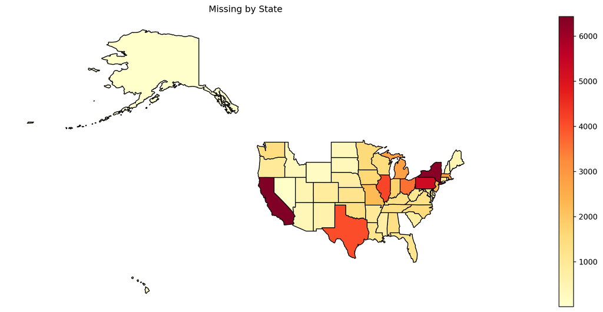

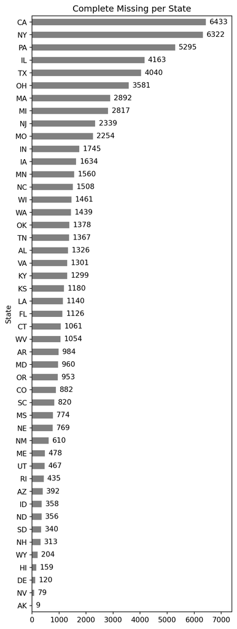

**Date of Loss**

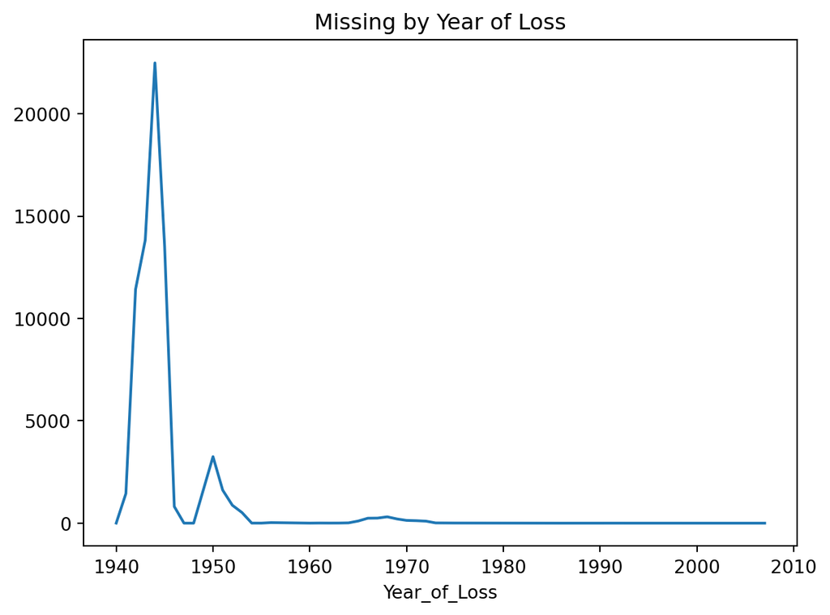

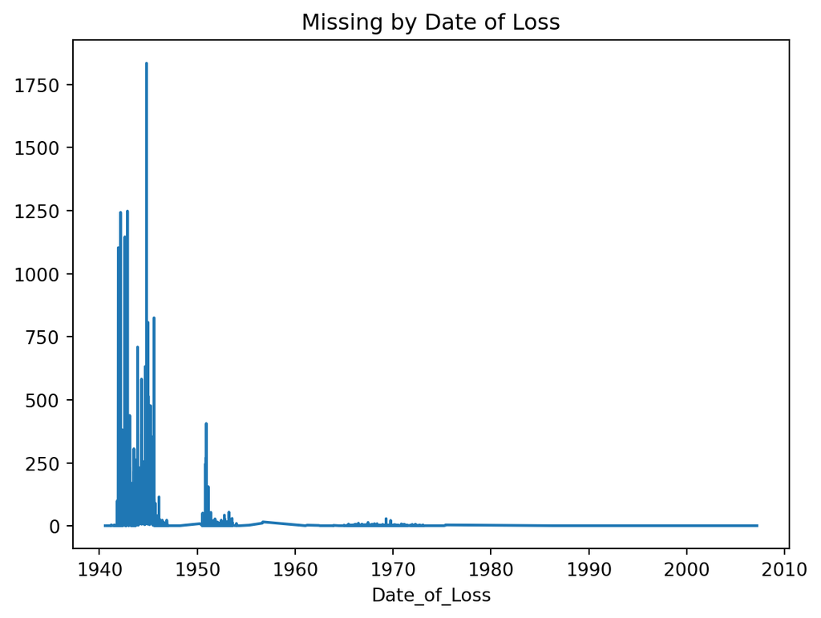

**Missing by Location of Loss**

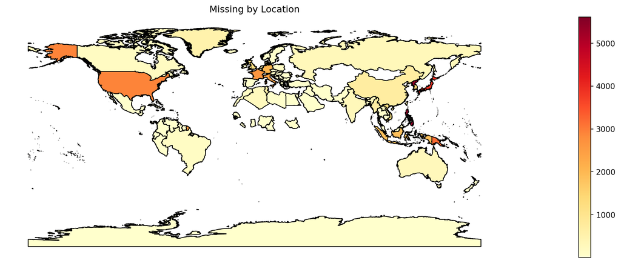

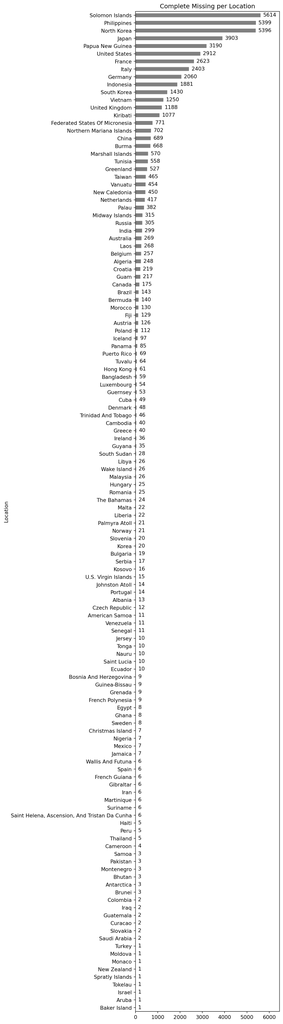

**Conflict Breakdown per Service**

```
Service                     AIR FORCE   ARMY  CIVILIAN  COAST GUARD  \
Conflict
COLD WAR                        45.97   0.00      1.61         0.00
KOREAN WAR                      12.65  74.65      0.00         0.00
OPERATION DESERT STORM           0.00   0.00      0.00         0.00
OPERATION EL DORADO CANYON     100.00   0.00      0.00         0.00
OPERATION IRAQI FREEDOM          0.00   0.00    100.00         0.00
VIETNAM WAR                     31.06  32.14      1.42         0.00
WORLD WAR II                    30.28  18.35      0.07         0.86

Service                     MARINE CORPS  MERCHANT MARINE    NAVY
Conflict
COLD WAR                            0.81             0.00   51.61
KOREAN WAR                          8.83             0.01    3.86
OPERATION DESERT STORM              0.00             0.00  100.00
OPERATION EL DORADO CANYON          0.00             0.00    0.00
OPERATION IRAQI FREEDOM             0.00             0.00    0.00
VIETNAM WAR                        12.96             0.00   22.42
WORLD WAR II                        4.02             0.04   46.37
```

The following pie charts show the breakdown of service missing per conflict

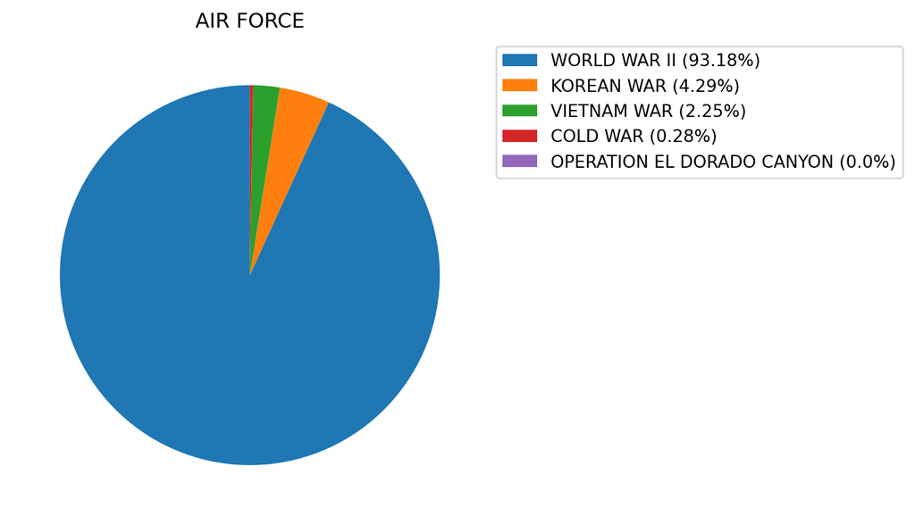

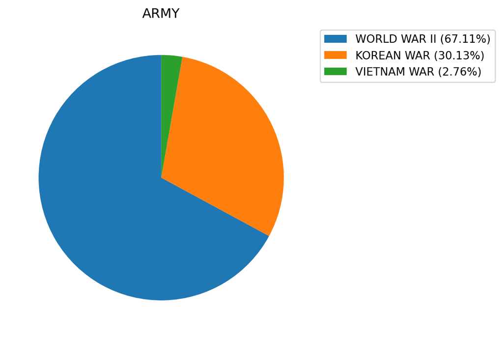

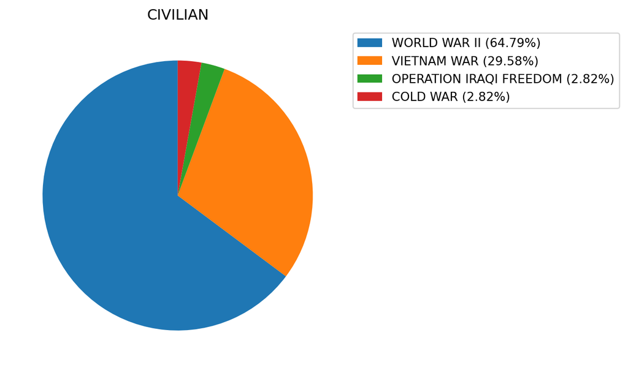

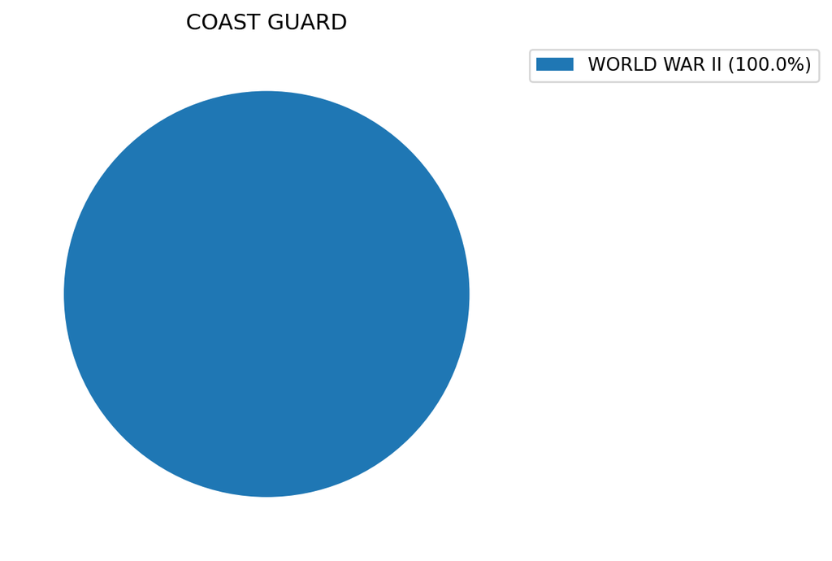

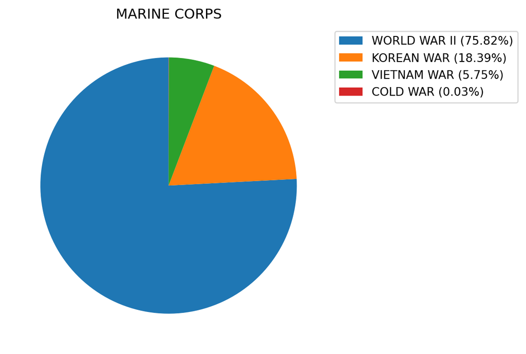

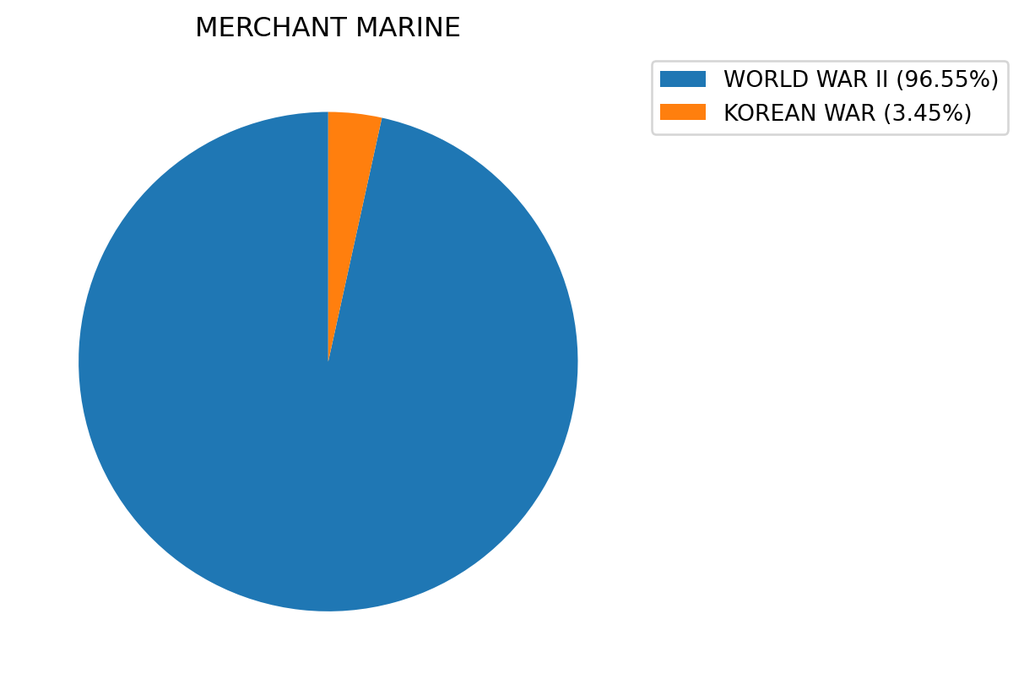

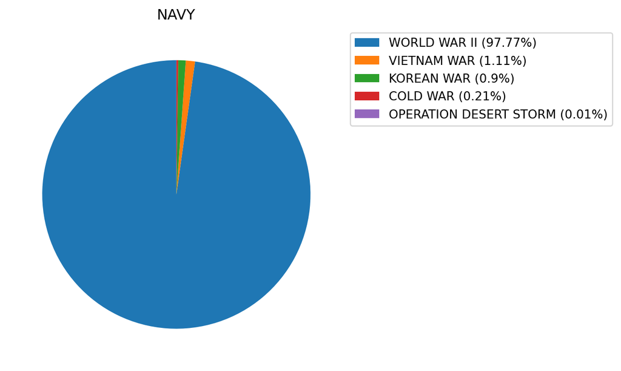

**Conflict Analysis**

I am combining the conflicts beside World War II, the Korean War, and the Vietnam War into “Other Conflicts” maps in order to more clearly show the data since they make up such a small percentage of the missing.

#### World War II: Missing by Home State

[Interactive map](http://htmlpreview.github.io/?https://github.com/reric4/MIA_Data_Analysis/blob/main/Maps/ww2stmap.html)

#### World War II: Missing by Location of Loss

[Interactive map](http://htmlpreview.github.io/?https://github.com/reric4/MIA_Data_Analysis/blob/main/Maps/ww2locmap.html)

#### Korean War: Missing by Home State

[Interactive map](http://htmlpreview.github.io/?https://github.com/reric4/MIA_Data_Analysis/blob/main/Maps/kwarstmap.html)

#### Korean War: Missing by Location of Loss

[Interactive map](http://htmlpreview.github.io/?https://github.com/reric4/MIA_Data_Analysis/blob/main/Maps/kwarlocmap.html)

#### Vietnam War: Missing by Home State

[Interactive map](http://htmlpreview.github.io/?https://github.com/reric4/MIA_Data_Analysis/blob/main/Maps/vwarstmap.html)

#### Vietnam War: Missing by Location of Loss

[Interactive map](http://htmlpreview.github.io/?https://github.com/reric4/MIA_Data_Analysis/blob/main/Maps/vwarlocmap.html)

#### Other Conflicts: Missing by Home State

[Interactive map](http://htmlpreview.github.io/?https://github.com/reric4/MIA_Data_Analysis/blob/main/Maps/owarstmap.html)

#### Other Conflicts: Missing by Location of Loss

[Interactive map](http://htmlpreview.github.io/?https://github.com/reric4/MIA_Data_Analysis/blob/main/Maps/owarlocmap.html)

**Service Analysis**

I am also combining the other services beside the Army, Air Force, Navy, and Marine Corps because they as well make up a small percentage of the missing.

#### US Air Force: Missing by Home State

[Interactive map](http://htmlpreview.github.io/?https://github.com/reric4/MIA_Data_Analysis/blob/main/Maps/afstmap.html)

#### US Air Force: Missing by Location of Loss

[Interactive map](http://htmlpreview.github.io/?https://github.com/reric4/MIA_Data_Analysis/blob/main/Maps/aflocmap.html)

#### US Army: Missing by Home State

[Interactive map](http://htmlpreview.github.io/?https://github.com/reric4/MIA_Data_Analysis/blob/main/Maps/armystmap.html)

#### US Army: Missing by Location of Loss

[Interactive map](http://htmlpreview.github.io/?https://github.com/reric4/MIA_Data_Analysis/blob/main/Maps/armylocmap.html)

#### US Navy: Missing by Home State

[Interactive map](http://htmlpreview.github.io/?https://github.com/reric4/MIA_Data_Analysis/blob/main/Maps/navystmap.html)

#### US Navy Missing by Location of Loss

[Interactive map](http://htmlpreview.github.io/?https://github.com/reric4/MIA_Data_Analysis/blob/main/Maps/navylocmap.html)

#### US Marine Corps: Missing by Home State

[Interactive map](http://htmlpreview.github.io/?https://github.com/reric4/MIA_Data_Analysis/blob/main/Maps/mcstmap.html)

#### US Marine Corps: Missing by Location of Loss

[Interactive map](http://htmlpreview.github.io/?https://github.com/reric4/MIA_Data_Analysis/blob/main/Maps/mclocmap.html)

#### Other Services: Missing by Home State

[Interactive map](http://htmlpreview.github.io/?https://github.com/reric4/MIA_Data_Analysis/blob/main/Maps/osvcstmap.html)

#### Other Services: Missing by Location of Loss

[Interactive map](http://htmlpreview.github.io/?https://github.com/reric4/MIA_Data_Analysis/blob/main/Maps/osvclocmap.html)

**Conclusions**

World War II is overwhelmingly the originating conflict for the majority of MIA soldiers, as well as the highest percentage of loss for all of the services

Overall the US Navy has the most MIA soldiers.

California overall has the most MIA soldiers, although New York has more MIA from World War II than California does

California has the most MIA Navy and Marines, while New York has the most MIA Army, Air Force, and other services

The Solomon Islands have the highest concentration of MIA missing, including the highest concentration of Marine Corps and Navy missing, as well as the highest concentration of World War II missing.

North Korea has the highest concentration of both Korean War missing, and Army missing.

Papua New Guinea has the highest concentration of Air Force missing.

The highest concentration of missing from other conflicts is in Russia, while the highest concentration of missing from other services is Greenland.